# ETC5512: Instructions for Lab 7

Emi Tanaka

Week 7

**Please do Preparation *before* the tutorial!**

## 🎯 Objectives

In this tutorial, you will learn

- a bit about how to structure your projects
- to wrangle messy data into tidy data
- to integrate data from different sources for exploratory analysis
- to draw choropleth maps and cartograms

## 🔧 Preparation

1. **Set up your project folder**
   - RStudio > New Project > New Directory > New Project

     Save it in a directory of your choosing.

     You can call the project what you like, e.g. `etc5512-week07`.
   - Create folders called `data`, `analysis` and `notes` in the project root directory.
   - Add the [2016 Census Sample Household Form](https://www.abs.gov.au/ausstats/abs@.nsf/Lookup/2901.0Main%20Features802016/$FILE/2016%20Census%20Sample%20Household%20Form.pdf) under `notes` folder.
   - Add a [sample analysis Rmd](https://github.com/numbats/wcd/raw/master/materials/exercise.Rmd) file under `analysis` folder.
   - Add a README.md file in the project root directory. The easiest way to do this is to run the R command `usethis::use_readme_md()` from your project.
2. **Getting the census data**
   - Go to https://datapacks.censusdata.abs.gov.au/datapacks/ selecting the following options:
     - 2016 Census Datapacks
     - General Community Profile
     - All geographies
     - Vic

     The downloaded file would be called `2016_GCP_ALL_for_Vic_short-header.zip` with size of 118 MB.
   - Unzip this file and save the folder in under `data` folder.
3. **Getting the election data**
   - Go to https://results.aec.gov.au/ then select from the left side bar
     - 2019 federal election
     - Downloads

     Scroll down and download the CSV file from *Distribution of preferences by candidate by division*. The file is named `HouseDopByDivisionDownload-24310.csv` (or you can downlaod by clicking [here](https://results.aec.gov.au/24310/Website/Downloads/HouseDopByDivisionDownload-24310.csv)).
   - Save this csv file in your project directory under the `data` folder.
4. **Installing relevant R-packages**

```r
install.packages(c("remotes", "usethis", "here", "skimr", "mgcv"))
# emitanaka should normally be replaced by reopenscilabs
remotes::install_github("emitanaka/eechidna")
```

5. **Check your project structure**

   Your project structure should look like below.

```
etc5512-week07
├── README.md
├── analysis
│   └── exercise.Rmd
├── data
│   ├── 2016_GCP_ALL_for_Vic_short-header
│   │   └── 2016\ Census\ GCP\ All\ Geographies\ for\ VIC
│   │       ├── SA1
│   │       │   └── VIC
│   │       │       ├── 2016Census_G17A_VIC_SA1.csv
│   │       │       ├── 2016Census_G17B_VIC_SA1.csv
│   │       │       └── 2016Census_G17C_VIC_SA1.csv
│   │       └── STE
│   │           └── VIC
│   │               ├── 2016Census_G17A_VIC_STE.csv
│   │               ├── 2016Census_G17B_VIC_STE.csv
│   │               └── 2016Census_G17C_VIC_STE.csv
│   └── HouseDopByDivisionDownload-24310.csv
├── etc5512-week07.Rproj
└── notes
    └── 2016\ Census\ Sample\ Household\ Form.pdf
```

- Note that it’s not desirable to have spaces in your file or folder name, as you may need escape spaces by preceding with `\` like above
- Put your analysis from the exercises into the `analysis/exercise.Rmd`.
- *Troubleshooting*: if you have an issue downloading datasets, installing software, running commands, and so on then you can make a permanent copy of [this RStudio Cloud project](https://rstudio.cloud/project/1218894) instead.

## 🏋 Exercise 7A

**Tidy your census data**

In the `setup` chunk, load the following packages.

```r
library(tidyverse)
library(eechidna)
# sometimes stats::filter is used instead of dplyr::filter
# so we explictly define which `filter` here
filter <- dplyr::filter
```

To load the data we will use the `here` function from the `here` package 📦. Note that we can use a function from a package without loading the package (i.e. without `library(package)`) by using the form `package::function`. The path argument parsed to `here::here` will be referenced with respect to `Rproj` is. This is particularly helpful if your project structure becomes deeply nested.

```
etc5512-week07
├── analysis
│   └── exercise.Rmd      # << analysis are here
├── data                  # << data are here
│
│
├── etc5512-week07.Rproj  # << make reference point `here`
```

```r
STE_path <- here::here("data/2016_GCP_ALL_for_Vic_short-header/2016 Census GCP All Geographies for VIC/STE/VIC/")
filenames <- paste0(STE_path, "2016Census_G17", c("A", "B", "C"), "_VIC_STE.csv")
STE_G17A_df <- read_csv(filenames[1], col_types = list())
STE_G17B_df <- read_csv(filenames[2], col_types = list())
STE_G17C_df <- read_csv(filenames[3], col_types = list())

SA1_path <- here::here("data/2016_GCP_ALL_for_Vic_short-header/2016 Census GCP All Geographies for VIC/SA1/VIC/")
filenames <- paste0(SA1_path, "2016Census_G17", c("A", "B", "C"), "_VIC_SA1.csv")
SA1_G17A_df <- read_csv(filenames[1], col_types = list())
SA1_G17B_df <- read_csv(filenames[2], col_types = list())
SA1_G17C_df <- read_csv(filenames[3], col_types = list())
```

First focus on `STE_G17A_df` alone.

To examine the data in the first instance use `skimr::skim`.

```r
skimr::skim(STE_G17A_df)
```

- How many rows and columns does `STE_G17A_df` contain?
- Remove any columns with the header that contains the strings `Tot` (totals) or `PI_NS` (personal income not stated).
- Wrangle your data so that it has the columns: `count`, `sex`, `age_min`, `age_max` `income_min`, and `income_max`. Below in the hint is some code to get you started (you will need to replace all the `...`s). For those with no upper bound (e.g. 85 over, 3000 or more), you can use `Inf` in R to signify $\infty$.

**Hint**

```r
STE_G17A_tidy_df <- pivot_longer(STE_G17A_df, -STE_CODE_2016,
                                 names_to = "category", values_to = "count") %>%
   filter(!str_detect(category, "Tot") | ... ) %>%
   mutate(  sex = case_when(
                    str_starts(category, "M") ~ "male",
                    str_starts(category, "F") ~ "female",
                    str_starts(category, "P") ~ "both"),
        age_min = case_when(
                    str_detect(category, "85_yrs_ovr") ~ 85,
                    str_detect(category, "85ov") ~ 85,
                    # use regular expression or otherwise for rest
                    TRUE ~ as.numeric(str_match(category, ".+_([0-9]+)_[0-9]+_yrs")[, 2])),
        age_max = case_when(...),
     income_min = case_when(...),
     income_max = case_when(...))
```

The first 10 rows of `STE_G17A_tidy_df` should look similar to below.

| STE_CODE_2016 | category | count | sex | income_min | income_max | age_min | age_max |
| --- | --- | --- | --- | --- | --- | --- | --- |
| 2 | M_Neg_Nil_income_15_19_yrs | 88338 | male | 0 | 0 | 15 | 19 |
| 2 | M_Neg_Nil_income_20_24_yrs | 31685 | male | 0 | 0 | 20 | 24 |
| 2 | M_Neg_Nil_income_25_34_yrs | 21321 | male | 0 | 0 | 25 | 34 |
| 2 | M_Neg_Nil_income_35_44_yrs | 12176 | male | 0 | 0 | 35 | 44 |
| 2 | M_Neg_Nil_income_45_54_yrs | 12700 | male | 0 | 0 | 45 | 54 |
| 2 | M_Neg_Nil_income_55_64_yrs | 16883 | male | 0 | 0 | 55 | 64 |
| 2 | M_Neg_Nil_income_65_74_yrs | 11502 | male | 0 | 0 | 65 | 74 |
| 2 | M_Neg_Nil_income_75_84_yrs | 4864 | male | 0 | 0 | 75 | 84 |
| 2 | M_Negtve_Nil_incme_85_yrs_ovr | 1736 | male | 0 | 0 | 85 | Inf |
| 2 | M_1_149_15_19_yrs | 38027 | male | 1 | 149 | 15 | 19 |

- Repeat to make `STE_G17B_df` and `STE_G17C_df` tidy.
- Combine `STE_G17A_tidy_df`, `STE_G17B_tidy_df` and `STE_G17C_tidy_df` data by bindng rows and save it to the variable `STE_G17_tidy_df`.

**Hint**

```r
STE_G17_tidy_df <- bind_rows(STE_G17A_tidy_df,
                             STE_G17B_tidy_df,
                             STE_G17C_tidy_df)
```

- Repeat now to get `SA1_G17_tidy_df`.

## 🏃 Exercise 7B

**Quality check your census data**

- According to the data from 7A, how many people are there in Victoria? If you check [http://www.population.net.au](http://www.population.net.au/population-of-victoria/), there are 6.03 million people in 2016 at Victoria. Does it look right? Are we missing some people in the data? If so, what kinds of people are we missing?
- What is the minimum and maximum of values for `count`? Do the range and categories for each column look right?
- Draw a barplot (using `ggplot` or otherwise) of the number people in Victoria by:
  1. sex
  2. age group
  3. income group
  4. sex and age group
  5. sex and income group
  6. age and income group
  7. sex, age and income group

**Hint: click here for a code for the 7th barplot**

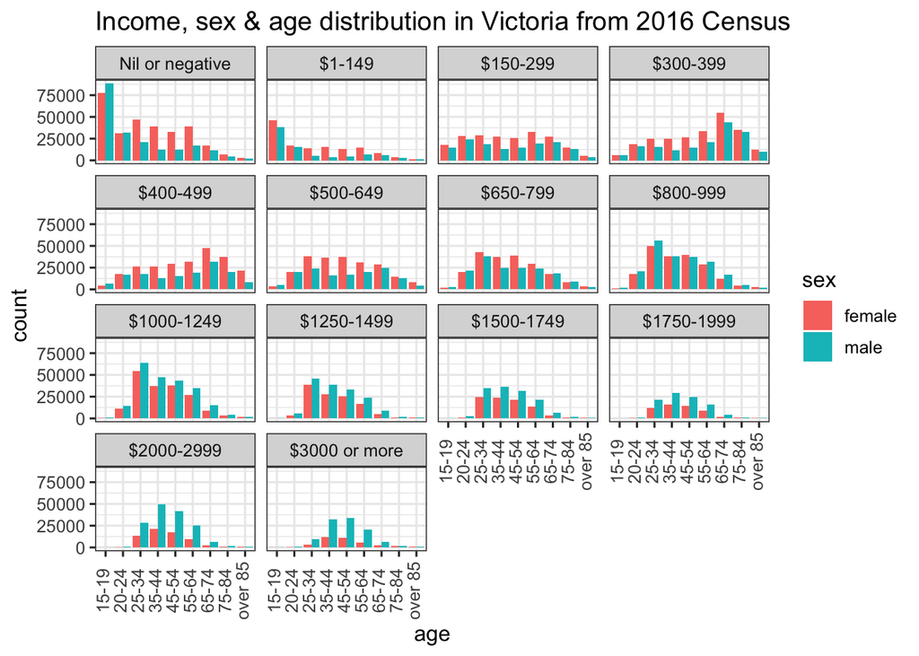

```r
STE_G17_tidy_df %>%
   # remove `both` (should be a combination of female + male)
   filter(sex!="both") %>%
   # make pretty age and income factors
   mutate(income = fct_reorder(paste0(scales::dollar(income_min, big.mark = ""), "-", income_max), income_min),
          income = fct_recode(income,
                              "Nil or negative" = "$0-0",
                              "$3000 or more" = "$3000-Inf"),
             age = fct_reorder(paste0(age_min, "-", age_max), age_min),
             age = fct_recode(age, "over 85" = "85-Inf")) %>%
   # plot
   ggplot(aes(x = age, y = count, fill = sex)) +
      geom_col(position = "dodge") +
   facet_wrap(~income) +
   # let's not use the default theme
   theme_bw(base_size = 12) +
   theme(axis.text.x = element_text(angle = 90, vjust = 0.3)) +
   ggtitle("Income, sex & age distribution in Victoria from 2016 Census")
```

- Do the graphs look right? Discuss with your classmates.

## 💃 Exercise 7C

**Extract statistics from your tidy census data**

According to the 2016 Census data:

- How many women in Victoria are aged between 15-54 years old?
- What is the proportion of people in Victoria that are 25-34 years old (inclusive) and earn $1750 or more per week?
- Suppose I randomly select a man from all the man aged 25-44 years old in Victoria. What is the probability that the man I selected earns less than $1500 per week?

## 🤺 Exercise 7D

**Map the election data**

We will next draw a map of Victoria and color the electorate districts with the political party that won that district in the 2019 federal election.

- First, import the election data and map data as below.

```r
election_2019_df <- read_csv(here::here("data/HouseDopByDivisionDownload-24310.csv"),
                        skip = 1, # first row is meta data
                        # below *explicitly* defines the column types
                        # note e.g. DivisionID is normally read as numeric
                        # but we specify it should be read as character
                        col_types = cols(
                             StateAb = col_character(),
                             DivisionID = col_character(),
                             DivisionNm = col_character(),
                             CountNumber = col_double(),
                             BallotPosition = col_character(),
                             CandidateID = col_character(),
                             Surname = col_character(),
                             GivenNm = col_character(),
                             PartyAb = col_character(),
                             PartyNm = col_character(),
                             Elected = col_character(),
                             HistoricElected = col_character(),
                             CalculationType = col_character(),
                             CalculationValue = col_double())) %>%
   # select winning candidate only
   filter(CalculationType == "Preference Count" &
             Elected == "Y" &
             CountNumber == 0) %>%
   # make division name upper case so
   # it can be joined later with map data
   mutate(elect_div = toupper(DivisionNm)) %>%
   # select only the variables needed
   select(elect_div, PartyAb)

# map data from the eechidna package
nat_map19 <- nat_map_download(2019)

# define the political colors (feel free to change)
party_colors <- c("ALP" = "#DE3533", "LNP" = "#ADD8E6",
                  "KAP" = "#8B0000", "GRN" = "#10C25B",
                  "GVIC" = "#10C25B", "XEN" = "#ff6300",
                  "LP" = "#0047AB", "NP" = "#0a9cca",
                  "IND" = "#000000")
```

- Next subset the `nat_map19` data to Victoria only and add a column `PartyAb` that corresponds to the 2019 federal election winner of that district. Save this data to a variable named `vic_map19`.

**Solution**

```r
vic_map19 <- nat_map19 %>%
   filter(state == "VIC") %>%
   left_join(election_2019_df, by = "elect_div")
```

- Draw a map that looks like below using `vic_map19`.

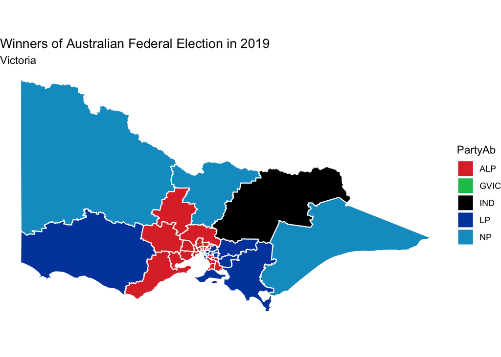

**Solution**

```r
plot_vic_map19 <- ggplot(vic_map19, aes(long, lat)) +
     geom_polygon(aes(group = group, fill = PartyAb),
                  color = "white") +
     theme_void() +
     coord_equal() +
     scale_fill_manual(values = party_colors) +
   ggtitle("Winners of Australian Federal Election in 2019",
           subtitle = "Victoria")
plot_vic_map19
```

## 🏂 Exercise 7E

**Integrate data from different sources**

We will be using the SA1 2016 Census to map the age data in `SA1_G17_tidy_df` onto the map. The SA1 border shape files can be found [here](https://www.abs.gov.au/AUSSTATS/abs@.nsf/DetailsPage/1270.0.55.001July%202016?OpenDocument) but we will use the processed data with the centroids of SA1 regions already calculated for you. For those interested, you can find out the script that was used to process the data [here](https://github.com/ropenscilabs/eechidna/blob/master/data-raw/imputing-using-sa1/mapping-CD-to-electorate.R).

- Import the centroids data as below.

```r
# loads the variable `centroids_sa1_2016` with the centroids of SA1 for 2016 census
load(url("https://github.com/ropenscilabs/eechidna/raw/master/extra-data/centroids_sa1_2016.rda"))
# change to a tidy data frame
centroids_sa1_2016_df <- centroids_sa1_2016$data %>%
  mutate(long = centroids_sa1_2016$centroids@coords[, 1],
         lat  = centroids_sa1_2016$centroids@coords[, 2])
```

- Examine the centroids_sa1_2016_df

```r
skimr::skim(centroids_sa1_2016_df)
```

- Filter the centroids data so only centroids located within Victoria are saved. The `mgcv::in.out` function is useful to find out if a point is located within a given polygon.

**Solution**

```r
# get an indicator
ind <- mgcv::in.out(as.matrix(select(vic_map19, long, lat)),
                    as.matrix(select(centroids_sa1_2016_df, long, lat)))
centroids_vic_sa1_2016_df <- centroids_sa1_2016_df %>%
   filter(ind) %>%
   # change SA1_7DIGIT to numeric from factor
   # so columns can be joined later
   mutate(SA1_7DIGIT = as.numeric(as.character(SA1_7DIGIT)))
```

- Finally, we want to superimpose a point at each SA1 centroid that indicates if the population of those that are aged 45 or over is larger than population of 15-44 years old in that election district. The final map should look like below.

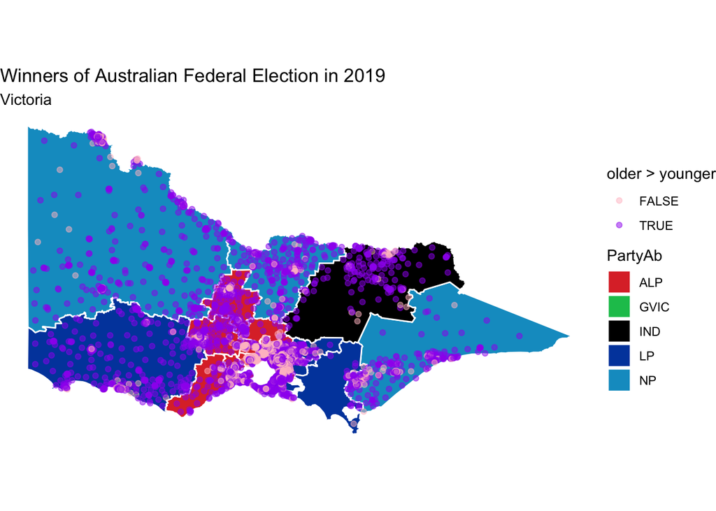

**Solution**

```r
aggregate_df <- SA1_G17_tidy_df %>%
   mutate(older = ifelse(age_min >= 45, "older", "younger")) %>%
   filter(sex == "both") %>%
   group_by(SA1_7DIGITCODE_2016, older) %>%
   summarise(count = sum(count)) %>%
   pivot_wider(SA1_7DIGITCODE_2016, names_from = older, values_from = count) %>%
   right_join(centroids_vic_sa1_2016_df, c("SA1_7DIGITCODE_2016"="SA1_7DIGIT"))

plot_vic_map19 +
   geom_point(data = aggregate_df,
              aes(x = long, y = lat, color = older > younger),
              alpha = 1/2) +
   scale_color_manual(values = c("TRUE" = "purple", "FALSE" = "pink"))
```

- From the above plot, the points around the city region is too dense to be very informative but do you notice anything for regional areas? Discuss with your classmates. You may try changing the threshold of 45 years to another age.